# RShiny and RMarkdown:Solutions to static reporting methods and perhaps the death of MS Word

Ben Block

28 February, 2022

[figure not shown]

# Content

1. Engaging constituents is important
2. Documents need to be digestible
3. Many orgs use science communication tools
4. User design should be considered
5. R Shiny can achieve these goals
6. Case study: This app!
7. Other considerations
8. Conclusions
9. References and Resources
10. Acknowledgments

## 1. Engaging constituents is important

> Informed and Involved Public Goal: Basin residents and visitors will understand and appreciate Lake Champlain Basin resources, and will possess a sense of personal responsibility that results in behavioral changes and actions to reduce pollution. ~ Lake Champlain Basin Program Opportunities for Action.
- Ensure constituents understand and appreciate natural resources
- Encourage personal responsibility and stewardship
- Inform policy makers on important issues
- Improve science literacy, equity, and inclusion

## 2. Documents need to be digestible

- Formal documents, required by the federal government, are necessary
- Not everyone has time to read formal documents front to back
- Integrated Report length by state (not including appendices):

| State | Report Length (Pages) |
| --- | --- |
| Connecticut | 62 |
| Maine | 212 |
| Massachusetts | 225 |
| New Hampshire | 119 |
| New York | 91 |
| Rhode Island | 56 |
| Vermont | 52 |

- [CT DEEP 2020 IWQR Factsheet](https://portal.ct.gov/-/media/DEEP/water/water_quality_management/305b/2020/IWQR2020Factsheet.pdf) is great!

[figure not shown]

## 3. Many orgs use science communication tools

- Puts information at the fingertips of stakeholders, public, and policy makers

[figure not shown]

## 4. User design should be considered

- Content is important; use a message box

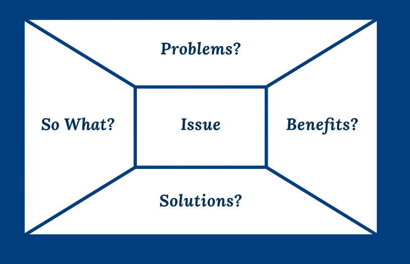

- But also consider effective delivery

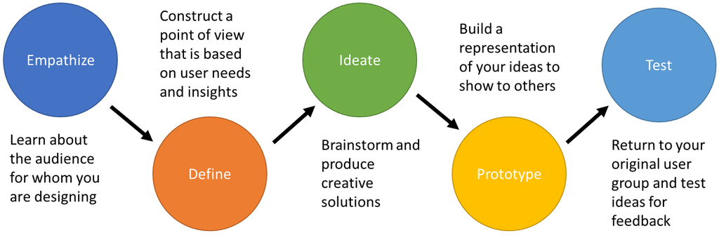

Figure adapted from Lauer, C. 2019.

## 5. R Shiny can achieve these goals

- R Shiny is a framework for creating web apps using R code
- Every Shiny app is maintained by a computer or server running R
- Does not require knowledge of HTML, CSS, or JavaScript
  - Simple option to use styling options include shinythemes and bslib packages

[figure not shown]

- Hosted on shinyapps.io

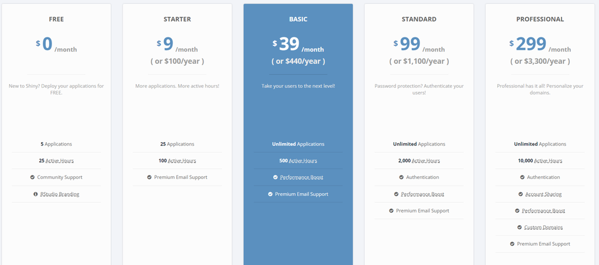

## 7. Other considerations

- Publicly available data
- Host R Shiny apps on your website
- Consider adding other media forms
- Share via social media
- Tetra Tech has broad experience making technical and non-technical content

## 8. Conclusions

- R Shiny is an excellent platform to create custom interactive outreach materials
- Formal documents are well suited for the government but not the public
- Science communication should be considered in every project
- **Public outreach should be a funded priority**

## 9. References and Resources

- Shiny Tutorials (https://shiny.rstudio.com/tutorial/)
- Markdown Tutorials (https://rmarkdown.rstudio.com/lesson-1.html)
- Shiny Gallery of Ideas (https://shiny.rstudio.com/gallery/)
- Markdown Gallery of Ideas (https://rmarkdown.rstudio.com/gallery.html)
- Mastering Shiny eBook (https://mastering-shiny.org/)
- Datacamp Self-Paced Tutorials (https://datacamp.com)
- Lauer, C. 2019. Cultivating mindfulness in the user experience of science communication.In SIGDOC ’19: The 37th ACM International Conference on the Design of Communication Proceedings, October 04–06, 2019, Portland, OR, USA.

## 10. Acknowledgments

[figure not shown]

This project has been funded wholly or in part by the United States Environmental Protection Agency under assistance agreement (I00199120-106) to NEIWPCC. The contents of this document do not necessarily reflect the views and policies of NEIWPCC or the EPA, nor does NEIWPCC or the EPA endorse trade names or recommend the use of commercial products mentioned in this document.